# Portfolio 4 , Methods 3, 2021, autumn semester

### *Dimensionality reduction; finding the signal among the noise*

**Author:** Mie Buchhave Søgaard  
**Student ID:** 202004812  
**Date:** 08.12.2021

## Exercises and objectives

1) Use principal component analysis to improve the classification of subjective experience  
2) Use logistic regression with cross-validation to find the optimal number of principal components

#### This portfolio has been done in collaboration with the study group:

```
Alina Kereszt (AK)
Linus Backström (LB)
Mikkel Kristensen (MK)
Mie Buchhave Søgaard (MS)
```

**Initials for the overall responsible person for each coding section will be specified in the beginning of each exercise, however, it should be noted that variable names, organization of code and print-statements might still vary. Comments in script as well as discussions and explanations are done individually.**

## Exercise 1 - Use principal component analysis to improve the classification of subjective experience

We will use the same files as we did in Assignment 3 The files `megmag_data.npy` and `pas_vector.npy` can be downloaded here (http://laumollerandersen.org/data_methods_3/megmag_data.npy) and here (http://laumollerandersen.org/data_methods_3/pas_vector.npy)  
The function `equalize_targets` is supplied - this time, we will only work with an equalized data set. One motivation for this is that we have a well-defined chance level that we can compare against. Furthermore, we will look at a single time point to decrease the dimensionality of the problem

### **1) Create a covariance matrix, find the eigenvectors and the eigenvalues**

Overall coding responsible for exercise 1, part 1: **MS**

**i. Load `megmag_data.npy` and call it `data` using `np.load`. You can use `join`, which can be imported from `os.path`, to create paths from different string segments**

```python
import numpy as np

np.random.seed(90)

data = np.load('megmag_data.npy')
y = np.load('pas_vector.npy')
```

**ii. Equalize the number of targets in `y` and `data` using `equalize_targets`**

```python
# Function provided by Lau
def equalize_targets(data, y):
    np.random.seed(7)
    targets = np.unique(y)
    counts = list()
    indices = list()
    for target in targets:
        counts.append(np.sum(y == target))
        indices.append(np.where(y == target)[0])
    min_count = np.min(counts)
    first_choice = np.random.choice(indices[0], size=min_count, replace=False)
    second_choice = np.random.choice(indices[1], size=min_count, replace=False)
    third_choice = np.random.choice(indices[2], size=min_count, replace=False)
    fourth_choice = np.random.choice(indices[3], size=min_count, replace=False)

    new_indices = np.concatenate((first_choice, second_choice,
                                 third_choice, fourth_choice))
    new_y = y[new_indices]
    new_data = data[new_indices, :, :]

    return new_data, new_y
```

```python
equalizer = equalize_targets(data, y)

data_eq = equalizer[0]
y_eq = equalizer[1]
```

**iii. Construct `times=np.arange(-200, 804, 4)` and find the index corresponding to 248 ms - then reduce the dimensionality of `data` from three to two dimensions by only choosing the time index corresponding to 248 ms (248 ms was where we found the maximal average response in Assignment 3)**

```python
times=np.arange(-200, 804, 4)

ix = np.where(times == 248)
print(f'Index for timestamp 248 is {ix[0]}')

X_248 = data_eq[:, :, 112]
```

```
Index for timestamp 248 is [112]
```

**iv. Scale the data using `StandardScaler`**

```python
from sklearn.preprocessing import StandardScaler

sc = StandardScaler()

X_248_sc = sc.fit_transform(X_248)
```

**v. Calculate the sample covariance matrix for the sensors (you can use `np.cov`) and plot it (either using `plt.imshow` or `sns.heatmap` (`import seaborn as sns`))**

```
(102, 102)
```

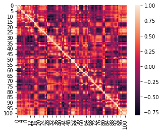

```python
import seaborn as sns

X_248_cov = np.cov(X_248_sc, rowvar = False)

print(X_248_cov.shape)

sns.heatmap(X_248_cov, square = True)
```

**vi. What does the off-diagonal activation imply about the independence of the signals measured by the 102 sensors?**

The off-diagonal activation imply that the measurements of the sensors do not seem to be totally independent from each other. If one took all measuremenent into account, one will end up overfitting and hurt prediction accuracy.

**vii. Run `np.linalg.matrix_rank` on the covariance matrix - what integer value do you get? (we'll use this later)**

```python
print(f'Matrix rank: {np.linalg.matrix_rank(X_248_cov)}')
```

```
Matrix rank: 97
```

**viii. Find the eigenvalues and eigenvectors of the covariance matrix using `np.linalg.eig` - note that some of the numbers returned are complex numbers, consisting of a real and an imaginary part (they have a *j* next to them). We are going to ignore this by only looking at the real parts of the eigenvectors and -values. Use `np.real` to retrieve only the real parts**

```python
eigenvalues, eigenvectors = np.linalg.eig(X_248_cov)

eigenvalues = np.real(eigenvalues)
eigenvectors = np.real(eigenvectors)
```

### **2) Create the weighting matrix $W$ and the projected data, $Z$**

Overall coding responsible for exercise 1, part 2: **LB**

**i. We need to sort the eigenvectors and eigenvalues according to the absolute values of the eigenvalues (use `np.abs` on the eigenvalues)**

```python
val_abs = np.abs(eigenvalues)
```

**ii. Then, we will find the correct ordering of the indices and create an array, e.g. `sorted_indices` that contains these indices. We want to sort the values from highest to lowest. For that, use `np.argsort`, which will find the indices that correspond to sorting the values from lowest to highest. Subsequently, use `np.flip`, which will reverse the order of the indices.**

```python
sorted_indices = np.argsort(val_abs)

sorted_indices = np.flip(sorted_indices)
```

**iii. Finally, create arrays of sorted eigenvalues and eigenvectors using the `sorted_indices` array just created. For the eigenvalues, it should look like this `eigenvalues = eigenvalues[sorted_indices]` and for the eigenvectors: `eigenvectors = eigenvectors[:, sorted_indices]`**

```python
eigenvalues_sort = eigenvalues[sorted_indices]
```

**iv. Plot the log, `np.log`, of the eigenvalues, `plt.plot(np.log(eigenvalues), 'o')` - are there some values that stand out from the rest? In fact, 5 (noise) dimensions have already been projected out of the data - how does that relate to the matrix rank (Exercise 1.1.vii)**

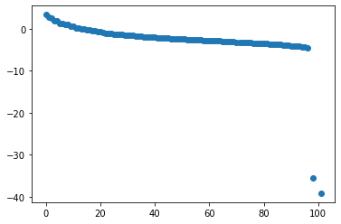

```python
import matplotlib.pyplot as plt

plt.plot(np.log(eigenvalues_sort), 'o', )
```

```python
# From 1.1.vii
print(f'Integer value: {np.linalg.matrix_rank(X_248_cov)}')
```

```
Integer value: 97
```

**v. Create the weighting matrix, `W` (it is the sorted eigenvectors)**

```python
W = eigenvectors[:, sorted_indices]
```

**vi. Create the projected data, `Z`, $Z = XW$ - (you can check you did everything right by checking whether the $X$ you get from $X = ZW^T$ is equal to your original $X$, `np.isclose` may be of help)**

```python
Z = X_248_sc @ W

X_check = Z @ W.T

np.isclose(X_248_sc, X_check)
```

```
array([[ True,  True,  True, ...,  True,  True,  True],
       [ True,  True,  True, ...,  True,  True,  True],
       [ True,  True,  True, ...,  True,  True,  True],
       ...,
       [ True,  True,  True, ...,  True,  True,  True],
       [ True,  True,  True, ...,  True,  True,  True],
       [ True,  True,  True, ...,  True,  True,  True]])
```

**vii. Create a new covariance matrix of the principal components (n=102) - plot it! What has happened off-diagonal and why?**

```
(396, 102)
```

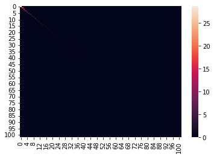

```python
new_cov = np.cov(Z, rowvar = False)
print(Z.shape)

sns.heatmap(new_cov)
```

## Exercise 2 - Use logistic regression with cross-validation to find the optimal number of principal components

### **1) We are going to run logistic regression with in-sample validation**

Overall coding responsible for exercise 2, part 1: **AK**

**i. First, run standard logistic regression (no regularization) based on $Z_{d \times k}$ and `y` (the target vector). Fit (`.fit`) 102 models based on: $k = [1, 2, ..., 101, 102]$ and $d = 102$. For each fit get the classification accuracy, (`.score`), when applied to $Z_{d \times k}$ and $y$. This is an in-sample validation. Use the solver `newton-cg` if the default solver doesn't converge**

```python
from sklearn.linear_model import LogisticRegression

log_reg = LogisticRegression(penalty = 'none', solver = 'newton-cg')

scores = np.zeros(shape = (102))

print(Z.shape)

Z = np.reshape(Z, newshape=(396, 102))

for i in range(102):
    if i == 0:
        hello = Z[:, 0]
        hello = hello.reshape(-1, 1)
    elif i == 102:
        hello = Z[:, :]
    else:
        hello = Z[:, 0:i+1]
    logm = log_reg.fit(hello, y_eq)
    score = logm.score(hello, y_eq)
    scores[i] = score
```

```
(396, 102)
```

**ii. Make a plot with the number of principal components on the *x*-axis and classification accuracy on the *y*-axis - what is the general trend and why is this so?**

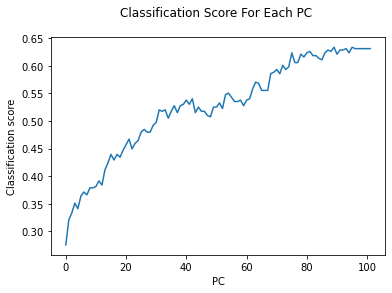

```python
plt.plot(scores)
#plt.axvline(x = times[max_0], color = 'red')
plt.title('Classification Score For Each PC \n')
plt.xlabel('PC')
plt.ylabel('Classification score')
plt.show()
```

**iii. In terms of classification accuracy, what is the effect of adding the five last components? Why do you think this is so?**

```python
print(f' The last five components: {scores[-6:-1]}')
```

```
 The last five components: [0.63131313 0.63131313 0.63131313 0.63131313 0.63131313]
```

The last five components does not improve the classification accuracy. The reason for that could be that there are so many components that adding more now does not contribute to classification performance. We also see that it is from that point that the eigenvalues drop (these are linearly dependent).

### 2) Now, we are going to use cross-validation

*we are using `cross_val_score` and `StratifiedKFold` from `sklearn.model_selection`*

Overall coding responsible for exercise 2, part 2: **MS**

**i. Define the variable: `cv = StratifiedKFold()` and run `cross_val_score` (remember to set the `cv` argument to your created `cv` variable). Use the same `estimator` in `cross_val_score` as in Exercise 2.1.i. Find the mean score over the 5 folds (the default of `StratifiedKFold`) for each $k$, $k = [1, 2, ..., 101, 102]$**

```python
from sklearn.model_selection import cross_val_score, StratifiedKFold

cv = StratifiedKFold() # default number of splits is 5

scores_cv = np.zeros(shape = (102))

for i in range(102):
    if i == 0:
        hello = Z[:, 0]
        hello = hello.reshape(-1, 1)
    elif i == 102:
        hello = Z[:, :]
    else:
        hello = Z[:, 0:i+1]
    logm = log_reg.fit(hello, y_eq)
    cv_score = cross_val_score(logm, hello, y_eq, cv = cv)
    score_mean = np.mean(cv_score)
    scores_cv[i] = score_mean
```

**ii. Make a plot with the number of principal components on the *x*-axis and classification accuracy on the *y*-axis - how is this plot different from the one in Exercise 2.1.ii?**

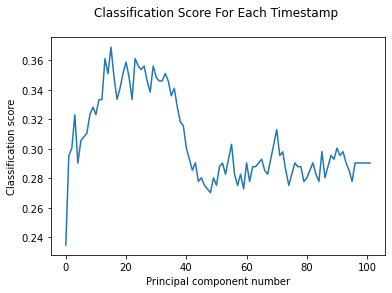

```python
plt.plot(scores_cv)
#plt.axvline(x = times[max_0], color = 'red')
plt.title('Classification Score For Each Timestamp \n')
plt.xlabel('Principal component number')
plt.ylabel('Classification score')
plt.show()
```

The plot is very different. The classification accuracy does not improve but instead fluctuates between .23-.36

**iii. What is the number of principal components, $k_{max\_accuracy}$, that results in the greatest classification accuracy when cross-validated?**

```python
max_val_index= np.argmax(scores_cv, axis = 0)

print(f'Maximum value score: {round(np.max(scores_cv), 4)}')
print(f'Principal component number: {max_val_index}')
```

```
Maximum value score: 0.3688
Principal component number: 15
```

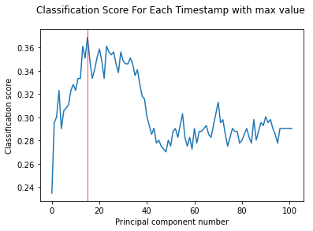

```python
plt.plot(scores_cv)
plt.axvline(x = max_val_index, color = 'red', linewidth = .7)
plt.title('Classification Score For Each Timestamp with max value \n')
plt.xlabel('Principal component number')
plt.ylabel('Classification score')
plt.show()
```

**iv. How many percentage points is the classification accuracy increased with relative to the to the full-dimensional, $d$, dataset**

```python
logm = log_reg.fit(Z, y_eq)
cv_score_all = cross_val_score(logm, Z, y_eq, cv = cv)
score_mean_all = np.mean(cv_score_all)

print(round(score_mean_all, 4))
```

```
0.2903
```

**v. How do the analyses in Exercises 2.1 and 2.2 differ from one another? Make sure to comment on the differences in optimization criteria.**

Just adding principal components one by one (exercise 2.1) seem to result in overfitting. Opposite, using crossvalidation seem to prevent overfitting to a greater extend, which especially is seen by the fact that classification accuracy starts decreasing after a certain point of principal components have been added.

### 3) We now make the assumption that $k_{max\_accuracy}$ is representative for each time sample (we only tested for 248 ms). We will use the PCA implementation from *scikit-learn*, i.e. import `PCA` from `sklearn.decomposition`.

Overall coding responsible for exercise 2, part 3: **MK**

```python
from sklearn.decomposition import PCA
```

**i. For **each** of the 251 time samples, use the same estimator and cross-validation as in Exercises 2.1.i and 2.2.i. Run two analyses - one where you reduce the dimensionality to $k_{max\_accuracy}$ dimensions using `PCA` and one where you use the full data. Remember to scale the data (for now, ignore if you get some convergence warnings - you can try to increase the number of iterations, but this is not obligatory)**

```python
import warnings
warnings.filterwarnings('ignore')

scores_all = np.zeros(shape = (251))

for i in range(251):
    X_time = data_eq[:, :, i]
    X_time_sc = sc.fit_transform(X_time)
    logm = log_reg.fit(X_time_sc, y_eq)
    all_score = cross_val_score(logm, X_time_sc, y_eq, cv = cv)
    score_all_mean = np.mean(all_score)
    scores_all[i] = score_all_mean
```

```python
pca = PCA(n_components = 15)

scores_pca_k = np.zeros(shape = (251))

for i in range(251):
    X_time_k = data_eq[:, :, i]
    X_time_k = sc.fit_transform(X_time_k)
    X_pca = pca.fit_transform(X_time_k)
    logm = log_reg.fit(X_pca, y_eq)
    pca_score_k = cross_val_score(logm, X_pca, y_eq, cv = cv)
    score_pca_mean = np.mean(pca_score_k)
    scores_pca_k[i] = score_pca_mean
```

**ii. Plot the classification accuracies for each time sample for the analysis with PCA and for the one without in the same plot. Have time (ms) on the *x*-axis and classification accuracy on the *y*-axis**

```python
plt.plot(times, scores_pca, color = 'darkgreen', linewidth = .9)
plt.plot(times, scores_pca_k, color = 'darkblue',linewidth = .9)
plt.title('Classification Score For Each Timestamp with and without PCA \n')
plt.axvline(x = 0, color = 'black', linestyle = ':')
plt.axvline(x = 400, color = 'black', linestyle = ':')
plt.xlabel('Time')
plt.ylabel('Classification score')
plt.legend(['Without PCA', 'With PCA'], loc = 'upper right')
plt.show()
```

[output not shown]

**iii. Describe the differences between the two analyses - focus on the time interval between 0 ms and 400 ms - describe in your own words why the logistic regression performs better on the PCA-reduced dataset around the peak magnetic activity**

```python
print(f'Mean classification accuracy on the whole dataset: {round(np.mean(scores_pca[50:151]), 4)}')

print(f'Mean classification accuracy on the PCA-reduced dataset: {round(np.mean(scores_pca_k[50:151]), 4)}')
```

[output not shown]

```python
plt.plot(times[50:151], scores_pca[50:151], color = 'darkgreen', linewidth = .9)
plt.plot(times[50:151], scores_pca_k[50:151], color = 'darkblue',linewidth = .9)
plt.title('Classification Score For 0-400 ms with and without PCA  \n')
plt.xlabel('Time')
plt.ylabel('Classification score')
plt.legend(['Without PCA', 'With PCA'], loc = 'upper right')
plt.show()
```

[output not shown]

The PCA has maintained the 15 most important features (15 sensors) for classifying PAS evaluation, and hereby leaving out features that might mainly contain noise but. Maintaining these features will then affect the classification but not contribute to better performance. This is what we probably see the consequences of in the classification on the whole dataset.